# The Project

1. This is a project with minimal scaffolding. Expect to use the the discussion forums to gain insights! It’s not cheating to ask others for opinions or perspectives!
2. Be inquisitive, try out new things.
3. Use the previous modules for insights into how to complete the functions! You'll have to combine Pillow, OpenCV, and Pytesseract
4. There are hints provided in Coursera, feel free to explore the hints if needed. Each hint provide progressively more details on how to solve the issue. This project is intended to be comprehensive and difficult if you do it without the hints.

### The Assignment

Take a ZIP file) of images and process them, using a [library built into python](https://docs.python.org/3/library/zipfile.html) that you need to learn how to use. A ZIP file takes several different files and compresses them, thus saving space, into one single file. The files in the ZIP file we provide are newspaper images (like you saw in week 3). Your task is to write python code which allows one to search through the images looking for the occurrences of keywords and faces. E.g. if you search for "pizza" it will return a contact sheet of all of the faces which were located on the newspaper page which mentions "pizza". This will test your ability to learn a new ([library](https://docs.python.org/3/library/zipfile.html)), your ability to use OpenCV to detect faces, your ability to use tesseract to do optical character recognition, and your ability to use PIL to composite images together into contact sheets.

Each page of the newspapers is saved as a single PNG image in a file called images.zip. These newspapers are in english, and contain a variety of stories, advertisements and images. Note: This file is fairly large (~200 MB) and may take some time to work with, I would encourage you to use small_img.zip for testing.

Here's an example of the output expected. Using the small_img.zip file, if I search for the string "Christopher" I should see the following image:

[figure not shown]

If I were to use the images.zip file and search for "Mark" I should see the following image (note that there are times when there are no faces on a page, but a word is found!):

[figure not shown]

Note: That big file can take some time to process - for me it took nearly ten minutes! Use the small one for testing.

```python
import zipfile as zf
from PIL import Image
from PIL import ImageFont
from PIL import ImageDraw
import pytesseract
import cv2 as cv
import numpy as np
from timeit import default_timer as timer

# loading the face detection classifier
face_cascade = cv.CascadeClassifier('readonly/haarcascade_frontalface_default.xml')

# reading zipfiles
# first list file names

myzip = zf.ZipFile('readonly/images.zip')
list_items = [str(z).split("'") for z in myzip.infolist()]
file_names = [x for y in list_items for x in y if "png" in x]
print(file_names)

# then extract all files, convert them into images and put them in a list "images"
images=[]
for item in file_names:
        pic_file = myzip.open(item)
        pic_image = Image.open(pic_file)
        pic_image = pic_image.convert("RGB")
        images.append(pic_image)
print(images)
```

[output not shown]

```python
# extract text from OCR-ed image

def OCR_output(img):
        img_gray = img.convert("L")
        img_gray.save('greyscale.jpg')
        text = pytesseract.image_to_string(Image.open('greyscale.jpg'))
        text_list = text.replace("\n"," ")
        return text_list


# prepare dict with all images data for all files


images_dict = {k:[] for k in ["Name","Image","Text"]}
start=round(timer(),2)
print(start)

for item in images:
    lap = round(timer(),2)
    k = images.index(item)
    images_dict["Name"].append(file_names[k])
    images_dict["Image"].append(item)
    images_dict["Text"].append(OCR_output(item))
    print(file_names[k])
    print(timer()-lap)

print(timer()-start)

# search key words
```

```
1462103.62
a-0.png
101.02366434107535
a-1.png
155.71074607409537
a-10.png
148.314721330069
a-11.png
84.3058952530846
a-12.png
85.183822266059
a-13.png
11.38679448608309
a-2.png
247.32372852391563
a-3.png
308.2002468579449
a-4.png
164.4791717210319
a-5.png
152.89406286692247
a-6.png
21.616028676042333
a-7.png
4.621979502029717
a-8.png
62.11828814493492
a-9.png
32.31544860615395
1579.615646200953
```

```python
# function to check if a given name is in the OCR-ed text
def check_scan_name(name):
    output = {}
    for item in images_dict['Text']:
            item_name = images_dict['Name'][images_dict['Text'].index(item)]
            item_image = images_dict['Image'][images_dict['Text'].index(item)]
            if name in item:
                    output[item_name] = item_image
    return output

# establish dictionary with images for "Christopher" and "Mark"
dict_images_C = check_scan_name("Christopher")
dict_images_M = check_scan_name("Mark")

print("For Christopher: {}".format(dict_images_C))
print("For Mark: {}".format(dict_images_M))
```

[output not shown]

```python
fnt = ImageFont.truetype("readonly/fanwood-webfont.ttf",size=15)

# function definition to treat images

# converts from  CV coordinates to PIL coordinates
def convert_coord(cv_XY):
    return (cv_XY[0],cv_XY[1],cv_XY[0]+cv_XY[2],cv_XY[1]+cv_XY[3])

# extracts recognized faces as cropped images and puts them in a list (to be used to build the contact sheet)
def extract_faces(faces_to_show,image_to_extract):
    image_faces_list = []
    for item in faces_to_show:
        coord_draw = convert_coord(item)
        image_cropped = image_to_extract.crop(coord_draw)
        image_faces_list.append(image_cropped)
    return image_faces_list

# makes individual contact sheets for each file. Inserts specific text if no face found

def make_contact_sheets(name_of_file,list_of_picture,width=500,height_row=100,height_text=20,Npic_byrow=5):

    N = len(list_of_picture)
    N_rows = ((N-1)//Npic_byrow+1)

    Height_sheet = N_rows*height_row
    Width_sheet = width
    Height_unit = height_row
    Width_unit = int(width/Npic_byrow)
    if list_of_picture==[]:
        output_sheet=Image.new("RGB", (Width_sheet+20, 2*height_text),color="white")
        draw = ImageDraw.Draw(output_sheet)
        draw.text((5,0),
                  "Results found in file {} \nBut there were no faces in that file!".format(name_of_file),
                  font=fnt,fill=(0,0,0))

    else:
        first_image=list_of_picture[0]

        output_sheet_base=Image.new(first_image.mode,
                               (Width_sheet, Height_sheet))

        x,y=0,0

        for item in list_of_picture:
            if item.width >=Width_unit or item.height>Height_unit:
                pic_to_add = item.resize((Width_unit,Height_unit))
            else:
                pic_to_add = item
            output_sheet_base.paste(pic_to_add, (x, y))
            if x+Width_unit == Width_sheet:
                     x=0
                     y=y+Height_unit
            else:
                     x=x+Width_unit
      # display(output_sheet_base)
        output_sheet=Image.new("RGB",
                               (output_sheet_base.width+20,output_sheet_base.height+height_text+5),
                                color="white")
        draw = ImageDraw.Draw(output_sheet)
        draw.text((5,0),"Results found in file {}".format(name_of_file),
                  font=fnt,fill=(0,0,0))
        output_sheet.paste(output_sheet_base,(5,height_text))
    return output_sheet
```

```python
# main function: takes a dictionary of image, identifies faces, calls subfunction to issue individual contact sheets (by file)
# and then put all of these together to produce a master contact sheet for all files relevant to the given name

def produce_contact_sheet(img_dict):

        contact_sheets=[]

        for name in img_dict.keys():
            #print(name)
            name_pic = name
            img = img_dict[name]
            img = img.convert("RGB")
            img_gray = img.convert("L")
            img_gray.save('greyscale.jpg')
            cv_image = cv.imread('greyscale.jpg')
            img_byte = cv.cvtColor(cv_image, cv.COLOR_BGR2GRAY)

            Scale_Factor = 1.3
            Min_neighbours=6
            faces = face_cascade.detectMultiScale(img_byte,scaleFactor=Scale_Factor, minNeighbors=Min_neighbours)

            if len(faces) ==0:
                list_faces=[]
            else:
                faces_list = faces.tolist()
               # print(len(faces_list))
                list_faces = extract_faces(faces_list,img)
            output_sheet=make_contact_sheets(name,list_faces)
            contact_sheets.append(output_sheet)

        Height_complete_sheet = sum([x.height for x in contact_sheets])
        Width_complete_sheet = max([x.width for x in contact_sheets])
        complete_sheet = Image.new("RGB",(Width_complete_sheet,Height_complete_sheet),color="white")
        x,y=0,0
        for item in contact_sheets:
            complete_sheet.paste(item,(x,y))
            y= y+item.height

        return complete_sheet
```

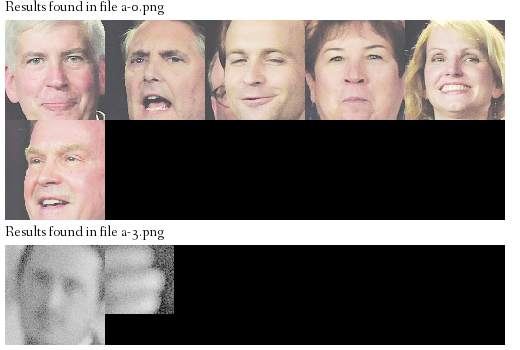

```python
# Now we just have to call this function for the dictionary of images relevant to Christopher
final_sheet_Christopher = produce_contact_sheet(dict_images_C)
display(final_sheet_Christopher)
```

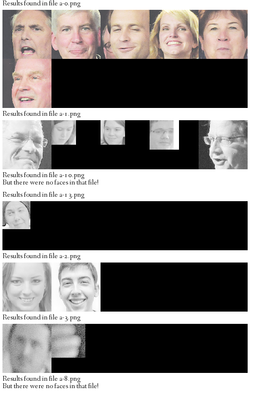

```python
# close enough :) and now for Mark
final_sheet_Mark = produce_contact_sheet(dict_images_M)
display(final_sheet_Mark)
```

```python
# order and fonts are different but the result fits
```